# Exploratory Data Analysis of real estate market in Texas

Mattia Guglielmelli

2023-03-18

Let’s start by importing the packages we will use and the dataset “realestate_texas.csv” on R:

```r
library(ggplot2)
library(dplyr)
library(moments)
library(stringr)
library(cowplot)

my_data <- read.csv("realestate_texas.csv")
```

In this way, we’ve created a DataFrame object with 240 observables of 8 variables. Let’s see the first 5 lines of the dataset:

```r
head(my_data, 5)
```

```
##       city year month sales volume median_price listings months_inventory
## 1 Beaumont 2010     1    83 14.162       163800     1533              9.5
## 2 Beaumont 2010     2   108 17.690       138200     1586             10.0
## 3 Beaumont 2010     3   182 28.701       122400     1689             10.6
## 4 Beaumont 2010     4   200 26.819       123200     1708             10.6
## 5 Beaumont 2010     5   202 28.833       123100     1771             10.9
```

The variables are:

- `city`: reference city. It is a variable of data type `character`, and therefore a **qualitative nominal variable**;
- `year`: reference year. Generically speaking, it is a **quantitative interval variable**, since it has not a clear definition of 0. In this case, it will be considered as a categorical variable, with 5 levels;
- `month`: reference month. It is an **encoded categorical variable**, with 12 levels;
- `sales`, `listings`: they are **quantitative discrete variables**. Going into detail, the variables contain the following information:
  - `sales`: total number of sales;
  - `listings`: total number of active listings.
- `volume`, `median_price`, `months_inventory`: they are **quantitative continuous variables**. Taking a closer look, they give us the following information:
  - `volume`: total value of sales in millions of dollars;
  - `median_price`: median sale price in dollars;
  - `months_inventory`: amount of time required to sell all the active listings at the current sales rate, in months.

As far as the variable `city` is concerned, we create the frequency distribution table. Before doing it, we use the function `attach()` to access variables of the DataFrame without selecting them by index or name from the DataFrame itself:

```r
attach(my_data)

#Construction of the frequency distribution table for the variable `city`:

N = dim(my_data)[1]
ni = table(city)
fi = ni/N
city_freq_distr <- cbind(ni,fi)
city_freq_distr
```

```
##                       ni   fi
## Beaumont              60 0.25
## Bryan-College Station 60 0.25
## Tyler                 60 0.25
## Wichita Falls         60 0.25
```

From the table, we realize that we are dealing with a **quadrimodal distribution**, since the absolute frequencies are the same for all the categories. Since the observations are uniformly distributed on the 4 categories, we expect the Gini index to be 1. Indeed:

```r
gini.index <- function(x){
  J <- length(table(x))
  fi2 <- (table(x)/length(x))^2
  G <- 1 - sum(fi2)
  gini <- G / ((J-1)/J)
  return(gini)
}

gini.index(city)
```

```
## [1] 1
```

The reason is that the dataset is made of data concerning the sales per month of the real estates of Beaumont, Bryan-College Station, Tyler and Wichita Falls, from 2010 to 2014. Therefore, we have $12\times5=60$ observations for each city. Indeed, if we consider, for example, the observations associated to the city “Beaumont”, we find 5 observations for each month and 12 observations for each year:

```r
Beaumont_data = filter(my_data, city == "Beaumont")
Beaumont_N = dim(Beaumont_data)[1]
ni = table(Beaumont_data$month)
fi = ni/Beaumont_N
Ni = cumsum(ni)
Fi = Ni/Beaumont_N
month_freq_distr <- cbind(ni,fi,Ni,Fi)
month_freq_distr
```

```
##    ni         fi Ni         Fi
## 1   5 0.08333333  5 0.08333333
## 2   5 0.08333333 10 0.16666667
## 3   5 0.08333333 15 0.25000000
## 4   5 0.08333333 20 0.33333333
## 5   5 0.08333333 25 0.41666667
## 6   5 0.08333333 30 0.50000000
## 7   5 0.08333333 35 0.58333333
## 8   5 0.08333333 40 0.66666667
## 9   5 0.08333333 45 0.75000000
## 10  5 0.08333333 50 0.83333333
## 11  5 0.08333333 55 0.91666667
## 12  5 0.08333333 60 1.00000000
```

```r
ni = table(Beaumont_data$year)
fi = ni/Beaumont_N
Ni = cumsum(ni)
Fi = Ni/Beaumont_N
year_freq_distr <- cbind(ni,fi,Ni,Fi)
year_freq_distr
```

```
##      ni  fi Ni  Fi
## 2010 12 0.2 12 0.2
## 2011 12 0.2 24 0.4
## 2012 12 0.2 36 0.6
## 2013 12 0.2 48 0.8
## 2014 12 0.2 60 1.0
```

The same holds for the remaining 3 cities. Therefore, according to the classic interpretation of probability, if we randomly extract an observation from the dataframe:

- the probability that the city is ‘Beaumont’ is equal to $60/240$, namely

```r
Beaumont_prob = Beaumont_N/N
Beaumont_prob
```

```
## [1] 0.25
```

- the probability that the month is July, i.e. 7, is equal to:

```r
July_data = filter(my_data, month == 7)
July_N = dim(July_data)[1]
July_prob = July_N/N
July_prob
```

```
## [1] 0.08333333
```

- the probability that the month is December, i.e. 12, and the year is 2012, is given by:

```r
dec2012_data = filter(my_data, month == 12 & year == 2012)
dec2012_N = dim(dec2012_data)[1]
dec2012_prob = dec2012_N/N
dec2012_prob
```

```
## [1] 0.01666667
```

We now move to compute the measures of position, the measures of variability and the measures of shape of the variables `sales`, `volume`, `median_price`, `listings` and `months_inventory`. To this aim, we build a summary table with all the statistical measures we want to compute:

```r
my_data.colnames <- colnames(my_data)
columns = c("min", "1st quartile", "median", "3rd quartile", "max", "range",
            "IQR", "mean", "std.dev", "var.coeff", "skewness", "kurtosis")
summary.df <- data.frame(matrix(nrow = 0, ncol = length(columns)))
colnames(summary.df) = columns

vc <- function(x){
  return(sd(x)/mean(x)*100)
}

for (variable.name in my_data.colnames[4:8]) {

  variable <- pull(my_data,variable.name)

  quartiles = as.numeric(quantile(variable))

  df <- my_data %>%
    summarise(range=max(variable)-min(variable),
              IQR=IQR(variable),
              mean=mean(variable),
              dev.st=sd(variable),
              var.coeff=vc(variable),
              skewness=skewness(variable),
              kurtosis=kurtosis(variable)-3)

  row = c(quartiles,as.numeric(df))

  summary.df <- rbind(summary.df, row)

}

summary.df <- cbind(my_data.colnames[4:8],summary.df)
colnames(summary.df) = c("variable", columns)
summary.df
```

```
##           variable       min 1st quartile      median 3rd quartile        max
## 1            sales    79.000     127.0000    175.5000      247.000    423.000
## 2           volume     8.166      17.6595     27.0625       40.893     83.547
## 3     median_price 73800.000  117300.0000 134500.0000   150050.000 180000.000
## 4         listings   743.000    1026.5000   1618.5000     2056.000   3296.000
## 5 months_inventory     3.400       7.8000      8.9500       10.950     14.900
##        range        IQR         mean      std.dev var.coeff    skewness
## 1    344.000   120.0000    192.29167    79.651111  41.42203  0.71810402
## 2     75.381    23.2335     31.00519    16.651447  53.70536  0.88474203
## 3 106200.000 32750.0000 132665.41667 22662.148687  17.08218 -0.36455288
## 4   2553.000  1029.5000   1738.02083   752.707756  43.30833  0.64949823
## 5     11.500     3.1500      9.19250     2.303669  25.06031  0.04097527
##     kurtosis
## 1 -0.3131764
## 2  0.1769870
## 3 -0.6229618
## 4 -0.7917900
## 5 -0.1744475
```

The `kurtosis` column allows us to conclude that the variables `sales`, `median_price`, `listings` and `months_inventory` have a negative kurtosis, thus their distributions are **platykurtic**, namely produce less extreme outliers than the normal distribution. On the other hand, the distribution of the variable `volume` is said to be **leptokurtic**, and therefore produces more outliers than the normal distribution. We can see what has been said by looking at the density plots of the variables:

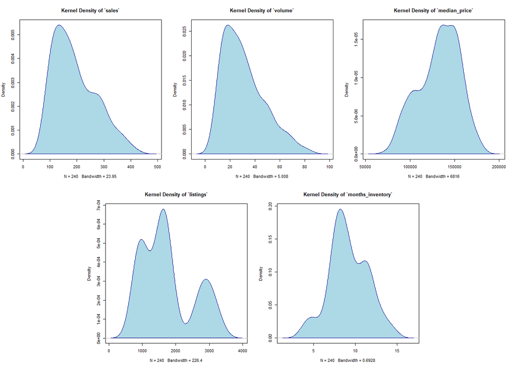

```r
layout(mat = matrix(c(1,1,2,2,3,3,
                      4,5,5,6,6,7),
                    nrow = 2,
                    byrow = T))

d1 <- density(sales)
d2 <- density(volume)
d3 <- density(median_price)
d4 <- density(listings)
d5 <- density(months_inventory)
plot(d1, main = "Kernel Density of `sales`")
polygon(d1, col = "lightblue", border = "darkblue")
plot(d2, main = "Kernel Density of `volume`")
polygon(d2, col = "lightblue", border = "darkblue")
plot(d3, main = "Kernel Density of `median_price`")
polygon(d3, col = "lightblue", border = "darkblue")
plot.new()
plot(d4, main = "Kernel Density of `listings`")
polygon(d4, col = "lightblue", border = "darkblue")
plot(d5, main = "Kernel Density of `months_inventory`")
polygon(d5, col = "lightblue", border = "darkblue")
plot.new()
```

If we now look at the Fisher-Pearson coefficient of skewness, we learn that, except for the median price, all the variables are positively skewed, namely their distribution is characterized by most of the values clustering around the left tail of the distribution, while the right tail of the distribution is longer. The distribution of the variable `median_price` is instead negatively skewed, meaning that the tail is on the left tail is longer than the right one, and the bulk of the distribution is concentrated on the right tail.

If we now remember that the coefficient of variation (CV) is a statistical measure of the *relative* dispersion of observations in a dataset around the mean, we find that the variable with the highest variability is the total value of sales in millions of dollars, namely the variable `volume`. The latter is also the variable with the highest degree of skewness, as can be seen from the column `skewness` of the table.

Before adding some interesting columns to the dataframe, let us divide the variable `volume` in classes and build the corresponding frequency distribution table. We choose to create 15 classes, in order to synthetize the data, without losing too much information:

```r
volume_classes <- cut(volume,
                      breaks = seq(min(volume), max(volume),
                                   (max(volume)-min(volume))/15))

ni <- table(volume_classes)
fi <- ni/N
Ni <- cumsum(ni)
Fi <- Ni/N

volume_freq_distr <- as.data.frame(cbind(ni,fi,Ni,Fi))

volume_freq_distr
```

```
##             ni          fi  Ni        Fi
## (8.17,13.2] 24 0.100000000  24 0.1000000
## (13.2,18.2] 42 0.175000000  66 0.2750000
## (18.2,23.2] 26 0.108333333  92 0.3833333
## (23.2,28.3] 30 0.125000000 122 0.5083333
## (28.3,33.3] 27 0.112500000 149 0.6208333
## (33.3,38.3] 22 0.091666667 171 0.7125000
## (38.3,43.3] 17 0.070833333 188 0.7833333
## (43.3,48.4]  9 0.037500000 197 0.8208333
## (48.4,53.4] 17 0.070833333 214 0.8916667
## (53.4,58.4]  5 0.020833333 219 0.9125000
## (58.4,63.4]  7 0.029166667 226 0.9416667
## (63.4,68.5]  5 0.020833333 231 0.9625000
## (68.5,73.5]  4 0.016666667 235 0.9791667
## (73.5,78.5]  2 0.008333333 237 0.9875000
## (78.5,83.5]  2 0.008333333 239 0.9958333
```

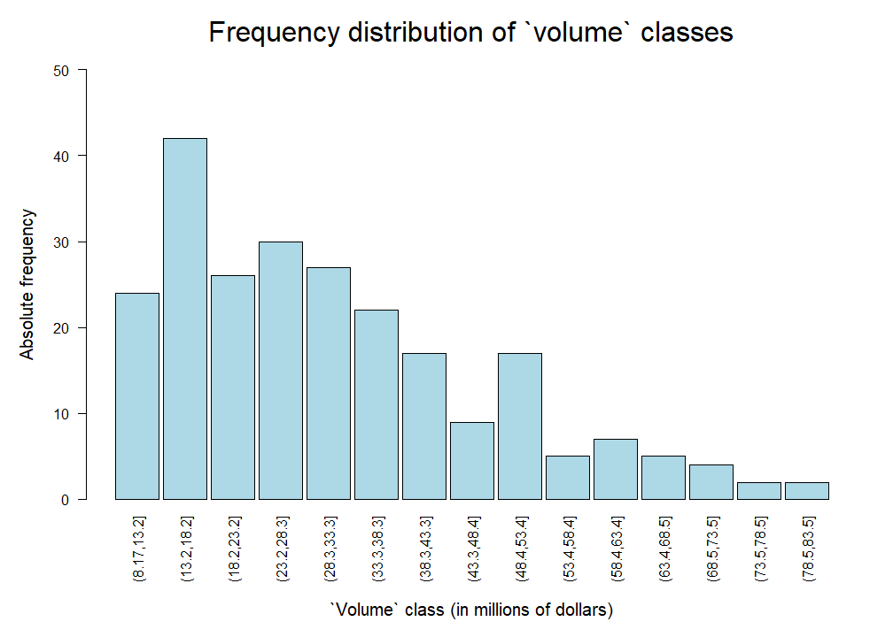

```r
par(mar = c(8,5,4,2) + 0.1)

barplot(volume_freq_distr$ni,
        xlab = "",
        ylab = "",
        ylim = c(0,50),
        main = "",
        col = "lightblue",
        space = 0.1,
        names.arg = rownames(volume_freq_distr),
        las = 2)

mtext(side=1,
      text="`Volume` class (in millions of dollars)",
      line=6,
      cex = 1.25)
mtext(side=2,
      text="Absolute frequency",
      line=3,
      cex = 1.25)
mtext(side=3,
      text="Frequency distribution of `volume` classes",
      line=1.5,
      cex = 2)
```

Finally, let us compute the Gini index of the variable `volume` divided in classes:

```r
gini.index(volume_classes)
```

```
## [1] 0.9614769
```

We now notice that we can compute the average price from the columns `sales` and `volume` of the dataframe, by dividing the total value of sales by the total number of sales. For convenience, let us also convert the average price in dollars:

```r
avg_price = volume/sales*1000000
my_data_with_avg_price = tibble::add_column(my_data,
                                            avg_price,
                                            .after = "volume")
head(my_data_with_avg_price,10)
```

```
##        city year month sales volume avg_price median_price listings
## 1  Beaumont 2010     1    83 14.162  170626.5       163800     1533
## 2  Beaumont 2010     2   108 17.690  163796.3       138200     1586
## 3  Beaumont 2010     3   182 28.701  157697.8       122400     1689
## 4  Beaumont 2010     4   200 26.819  134095.0       123200     1708
## 5  Beaumont 2010     5   202 28.833  142737.6       123100     1771
## 6  Beaumont 2010     6   189 27.219  144015.9       122800     1803
## 7  Beaumont 2010     7   164 22.706  138451.2       124300     1857
## 8  Beaumont 2010     8   174 25.237  145040.2       136800     1830
## 9  Beaumont 2010     9   124 17.233  138975.8       121100     1829
## 10 Beaumont 2010    10   150 23.904  159360.0       138500     1779
##    months_inventory
## 1               9.5
## 2              10.0
## 3              10.6
## 4              10.6
## 5              10.9
## 6              11.1
## 7              11.7
## 8              11.6
## 9              11.7
## 10             11.5
```

Based on the available data, we can also add another column that gives an idea of how much the sales offers are effective. Indeed, we can divide the total number of sales by the total number of active sales offers:

```r
sales_offers_efficiency = sales/listings
my_data_with_avg_and_efficiency = tibble::add_column(my_data_with_avg_price,
                                                     sales_offers_efficiency,
                                                     .after = "listings")
head(my_data_with_avg_and_efficiency,10)
```

```
##        city year month sales volume avg_price median_price listings
## 1  Beaumont 2010     1    83 14.162  170626.5       163800     1533
## 2  Beaumont 2010     2   108 17.690  163796.3       138200     1586
## 3  Beaumont 2010     3   182 28.701  157697.8       122400     1689
## 4  Beaumont 2010     4   200 26.819  134095.0       123200     1708
## 5  Beaumont 2010     5   202 28.833  142737.6       123100     1771
## 6  Beaumont 2010     6   189 27.219  144015.9       122800     1803
## 7  Beaumont 2010     7   164 22.706  138451.2       124300     1857
## 8  Beaumont 2010     8   174 25.237  145040.2       136800     1830
## 9  Beaumont 2010     9   124 17.233  138975.8       121100     1829
## 10 Beaumont 2010    10   150 23.904  159360.0       138500     1779
##    sales_offers_efficiency months_inventory
## 1               0.05414220              9.5
## 2               0.06809584             10.0
## 3               0.10775607             10.6
## 4               0.11709602             10.6
## 5               0.11405985             10.9
## 6               0.10482529             11.1
## 7               0.08831449             11.7
## 8               0.09508197             11.6
## 9               0.06779661             11.7
## 10              0.08431703             11.5
```

The new variable allows for a more unbiased comparison between the total number of sales of the 4 cities, being divided by total number of active sales offers. Let us then plot it, considering separately the 4 cities:

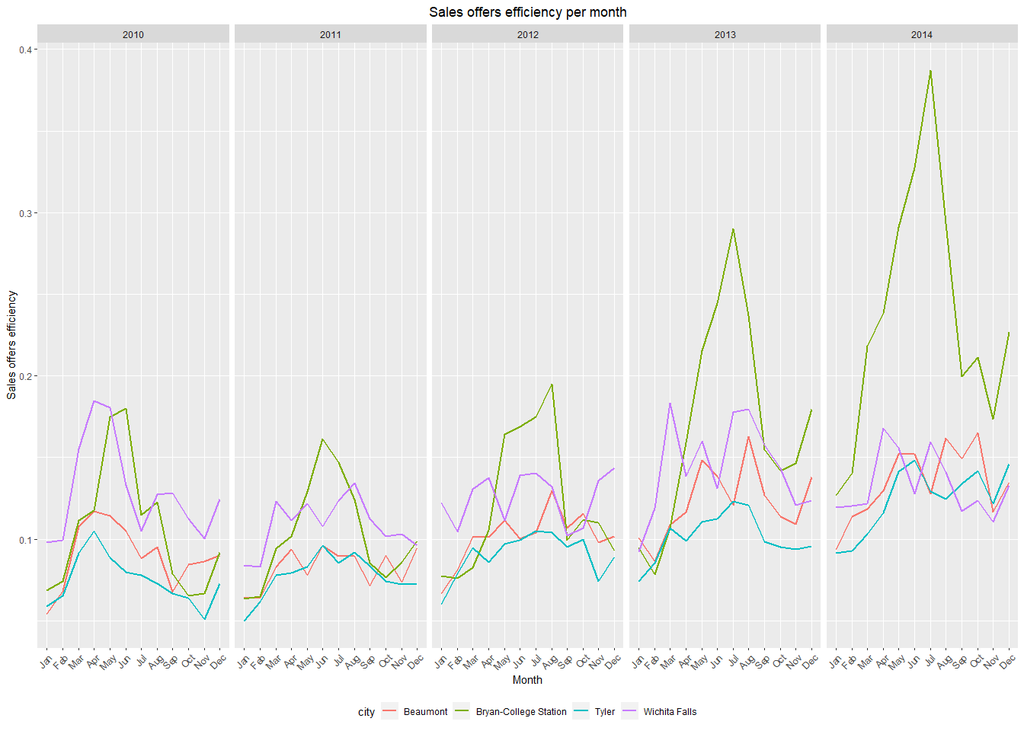

```r
ggplot(data = my_data)+
  geom_line(aes(x = factor(month.abb[month], levels = month.abb),
                y=sales_offers_efficiency,
                group=city,
                col=city),
            lwd=1
            )+
  facet_wrap(~year, nrow = 1)+
  scale_x_discrete(guide = guide_axis(angle = 45))+
  labs(x="Month",
       y="Sales offers efficiency",
       title = "Sales offers efficiency per month")+
  theme(plot.title = element_text(hjust = 0.5),
        legend.position = "bottom")
```

We see that in 2010 Wichita Falls was the city which, on average, had the best sales offers efficiency. However, while the sales offers efficiency of Wichita Falls stayed almost constant from 2010 to 2014, the one of Bryan-College Station grew steadily, to become the one with the best sales offers efficiency for every month in 2014.

We can also study how the sales offers efficiency depends on the month, by considering again the 4 cities separately. We can perform this analysis by exploiting the pipe operator:

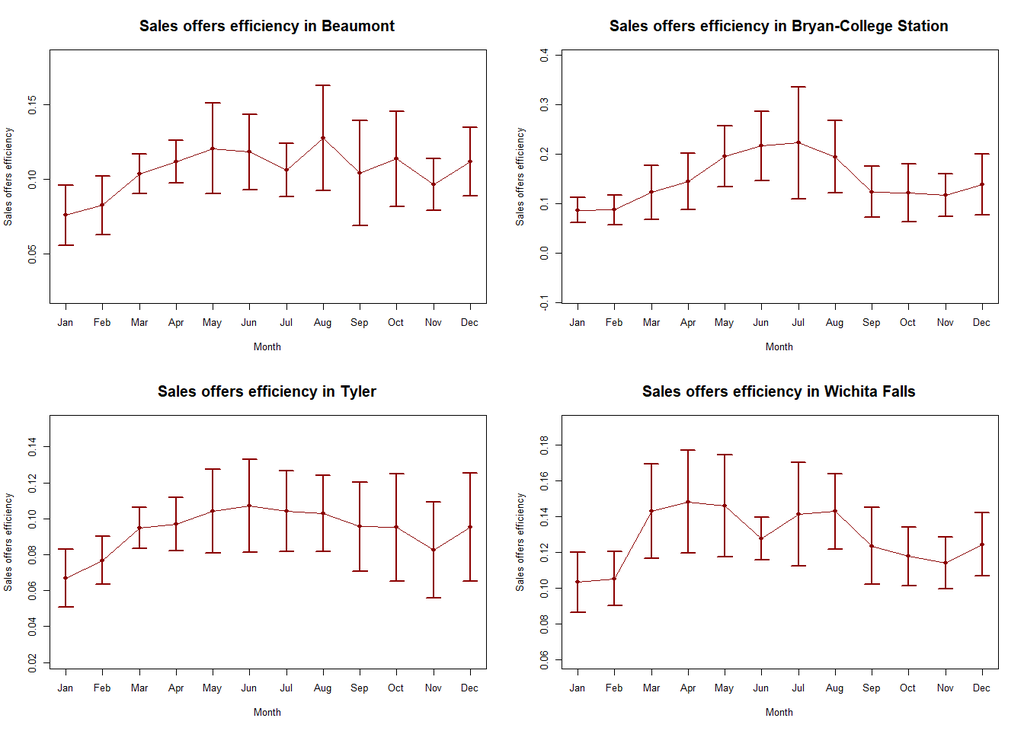

```r
cities = unique(city)
city.summaries = c()
par(mfrow=c(2,2))

for (i in cities) {

  city_data = filter(my_data_with_avg_and_efficiency, city == i)

  city_summary <- city_data %>%
  group_by(month)%>%
  summarise(mean = mean(sales_offers_efficiency),
            std.dev = sd(sales_offers_efficiency))

  city.summaries <- c(city.summaries, city_summary)

  plot(x=city_summary$month,
       y=city_summary$mean,
       type = "l",
       xlab = "Month",
       ylab = "Sales offers efficiency",
       ylim = c(min(city_summary$mean)-1.5*max(city_summary$std.dev),
                max(city_summary$mean)+1.5*max(city_summary$std.dev)),
       main = paste("Sales offers efficiency in", i, sep=" "),
       xaxt = "n",
       col = "darkred",
       cex.main = 1.5)
  points(x=city_summary$month,
       y=city_summary$mean,
       pch = 16,
       col = "darkred")
  arrows(x0=city_summary$month,
         y0=city_summary$mean-city_summary$std.dev,
         x1=city_summary$month,
         y1=city_summary$mean+city_summary$std.dev,
         code=3,
         angle=90,
         length=0.1,
         col="darkred",
         lwd=2)

  axis(1, at = seq(1,12,1), labels = month.abb)
}
```

Each point of the figure above is given by the mean of the efficiencies associated to a given month, with the corresponding error bars.  
For all the cities, the months with the lowest sales offers efficiency are January and February. Furthermore, the city that on average has the highest values of efficiency is Bryan-College Station, while the one with the lowest values is Tyler.

Let us now consider the boxplot illustrating the distribution of the median sale price per city:

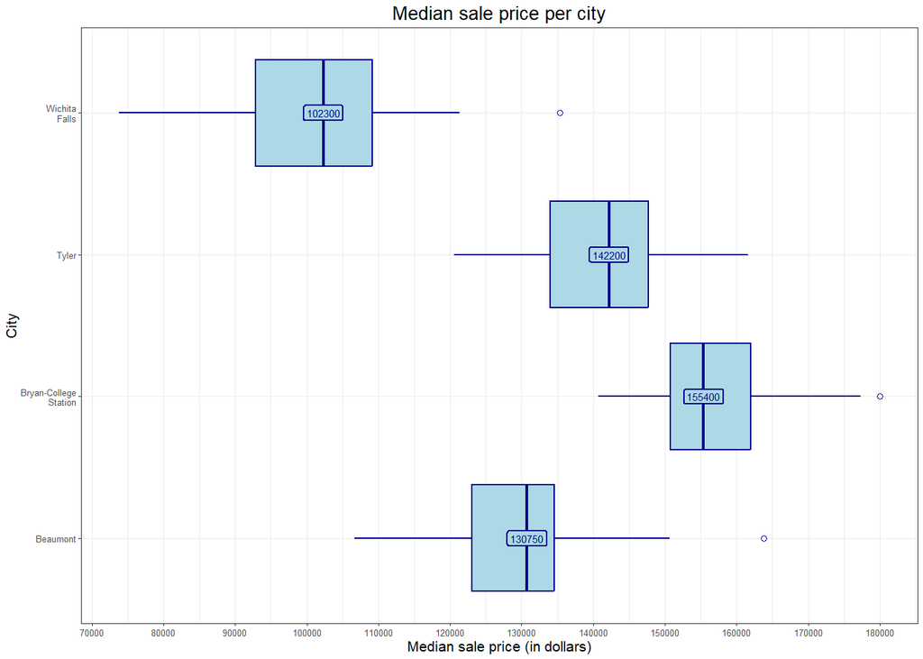

```r
city_labels <- c()

for (i in 1:length(unique(city))){

  city_labels<-c(city_labels,
                 paste(stringr::str_split_1(unique(city)[i], " "),
                       collapse = "\n"))

}



median_labels <- my_data%>%
  group_by(as.numeric(factor(city)))%>%
  summarise(city_name = unique(city),
            median_median_price = median(median_price))

ggplot()+
  geom_boxplot(aes(x=median_price,
                y=city),
               fill = "lightblue",
               colour = "darkblue",
               outlier.colour = "darkblue",
               outlier.shape = 1,
               outlier.size = 2.5,
               linewidth = 0.75,
               outlier.stroke = 0.75,
               )+
  scale_y_discrete(labels=city_labels)+
  scale_x_continuous(breaks = seq(70000,180000,10000))+
  labs(x="Median sale price (in dollars)",
       y="City",
       title = "Median sale price per city")+
  theme_bw()+
  theme(plot.title = element_text(size = 20, hjust = 0.5),
        axis.text.x = element_text(size = 10),
        axis.text.y = element_text(size = 10),
        axis.title = element_text(size = 16))+
  geom_label(aes(x=median_labels$median_median_price,
             y=median_labels$`as.numeric(factor(city))`,
             label=median_labels$median_median_price),
             fill = "lightblue",
             colour = "darkblue",
             label.size = 0.75)
```

The boxplot shows that the distribution of the median sale price of all cities is asymmetric. Furthermore, we learn that, on average, the city with the highest median sale price is Bryan-College Station, followed by Tyler, Beaumont and Wichita Falls, respectively.

Let us now build another boxplot with the total value of sales per year, considering again separately the 4 cities:

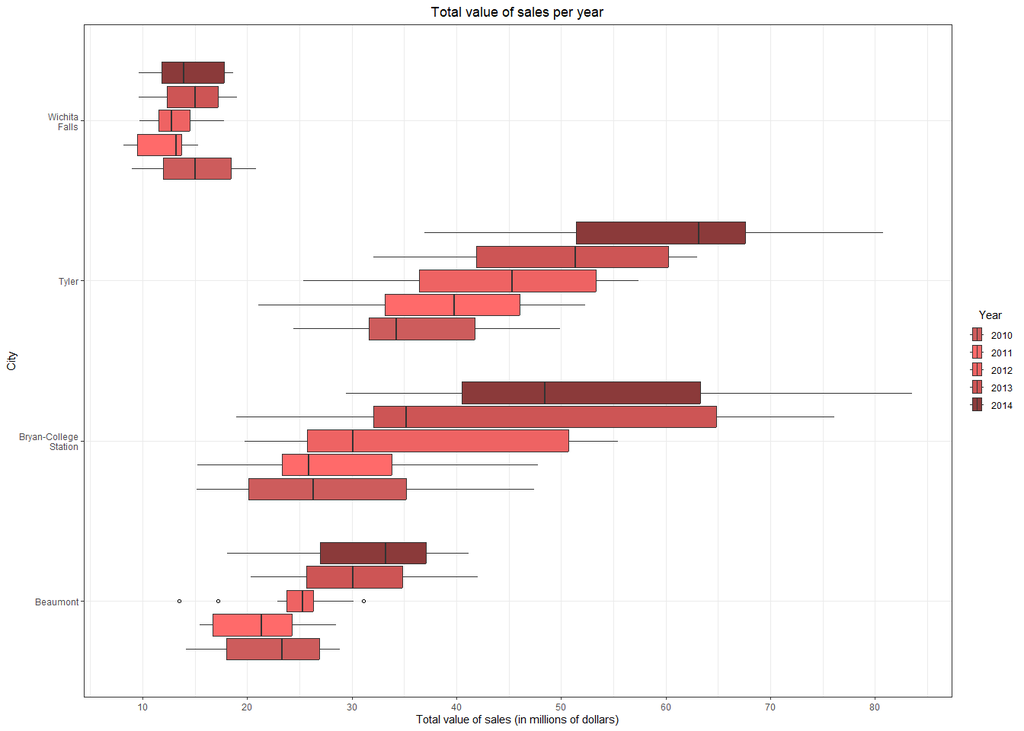

```r
ggplot(data = my_data)+
  geom_boxplot(aes(x=volume,
                y=city,
                fill=factor(year)),
               outlier.colour = "black",
               outlier.shape = 1
            )+
  scale_fill_manual(
    name = "Year",
    breaks = factor(unique(year)),
    values = c("indianred", "indianred1", "indianred2",
               "indianred3", "indianred4"),
    labels = as.character(unique(year))
  )+
  scale_y_discrete(labels=city_labels)+
  scale_x_continuous(breaks = seq(10,80,10))+
  labs(x="Total value of sales (in millions of dollars)",
       y="City",
       title = "Total value of sales per year")+
  theme_bw()+
  theme(plot.title = element_text(hjust = 0.5),
        legend.title.align = 0.5)
```

This chart allows us to see that, regardless of the year, the city with the highest median of the total value of sales is Tyler, followed by Bryan-College Station . Combined with the previous graph, we expect the total number of sales to be greater (on average) in Tyler than in Bryan-College Station, since the latter tends to have a higher median sale price than the former.  
We can extrapolate some other useful information from the plot. For example, it shows that the total value of sales per year:

- steadily increased in Tyler, Bryan-College Station and Beaumont;
- remained almost constant in Wichita Falls.

Let us look again at the total value of sales, by now showing the data not only per year, but per month, by means of a stacked bar chart:

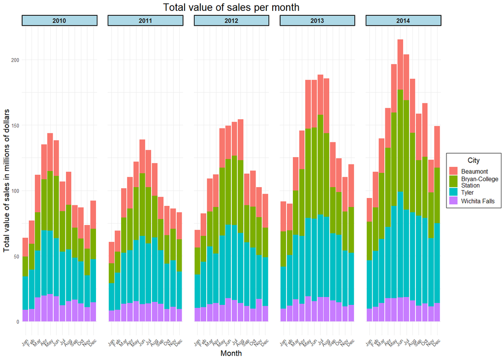

```r
ggplot(my_data)+
  geom_col(aes(x = factor(month.abb[month], levels = month.abb),
               y = volume,
               fill = city))+
  labs(x = "Month",
       y = "Total value of sales in millions of dollars",
       title = "Total value of sales per month")+
  facet_wrap(~year,nrow = 1)+
  scale_x_discrete(guide = guide_axis(angle = 45))+
  scale_fill_discrete(name = "City",
                      labels = str_wrap(unique(city), width = 15))+
  theme_minimal()+
  theme(plot.title = element_text(size= 20,
                                  hjust = 0.5),
        strip.text = element_text(size = 12,
                                  face = "bold"),
        strip.background = element_rect(color = "black",
                                        fill = "lightblue",
                                        linewidth = 1.2),
        legend.box.background = element_rect(color = "black",
                                             linewidth = 0.3),
        axis.text.x = element_text(size = 10),
        axis.text.y = element_text(size = 10),
        axis.title = element_text(size = 16),
        legend.text = element_text(size = 12),
        legend.title = element_text(size = 14),
        legend.title.align = 0.5,
        panel.spacing = unit(1.5, "lines"))
```

This chart illustrates that the months going from April to August are those reaching the highest sum of the total value of sales. Furthermore, it shows that there was an increase of the total value of sales in Texas from 2011 onwards, mostly due to the significant increase of the total value of sales in Bryan-College Station. This is even clearer by looking at the normalized stacked bar chart:

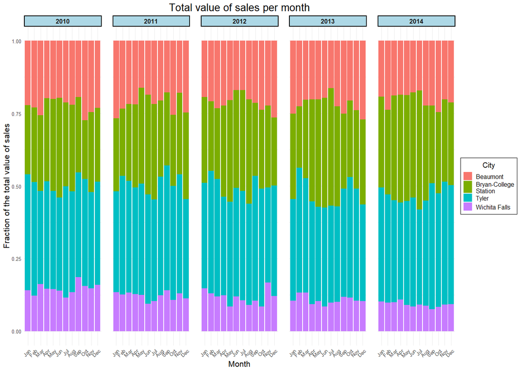

```r
ggplot(data = my_data)+
  geom_col(aes(x = factor(month.abb[month], levels = month.abb),
               y = volume,
               fill = city),
           position = "fill")+
  labs(x = "Month",
       y = "Fraction of the total value of sales",
       title = "Total value of sales per month")+
  facet_wrap(~year,nrow = 1)+
  scale_x_discrete(guide = guide_axis(angle = 45))+
  scale_fill_discrete(name = "City",
                      labels = str_wrap(unique(city), width = 15))+
  theme_minimal()+
  theme(plot.title = element_text(size= 20,
                                  hjust = 0.5),
        strip.text = element_text(size = 12,
                                  face = "bold"),
        strip.background = element_rect(color = "black",
                                        fill = "lightblue",
                                        linewidth = 1.2),
        legend.box.background = element_rect(color = "black",
                                             linewidth = 0.3),
        axis.text.x = element_text(size = 10),
        axis.text.y = element_text(size = 10),
        axis.title = element_text(size = 16),
        legend.text = element_text(size = 12),
        legend.title = element_text(size = 14),
        legend.title.align = 0.5,
        panel.spacing = unit(1.5, "lines"))
```

In addition, the following line chart contains the percentage of the total value of sales of each city per year:

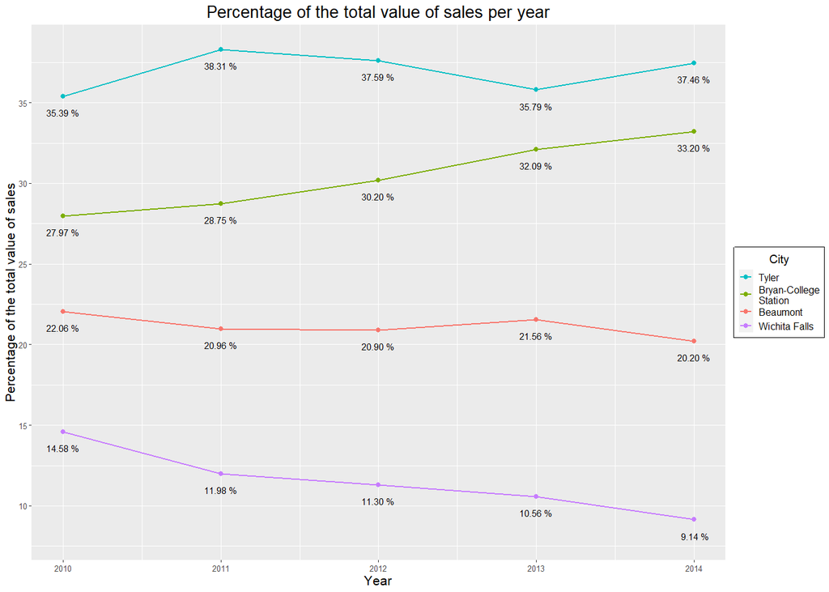

```r
total_per_year <- my_data %>%
  group_by(year)%>%
  summarise(total=sum(volume))

i = 1
years = unique(year)

for (yr in years) {

  percentage_per_city <- filter(my_data, year == yr) %>%
  group_by(city)%>%
  summarise(year = unique(year),
            percentage = sum(volume)/total_per_year$total[i])

  if (i==1) {

    percentage_per_year_and_city <- percentage_per_city

  } else {
    percentage_per_year_and_city <- rbind(percentage_per_year_and_city,
                                          percentage_per_city)
  }

  i <- i+1

}

swtch <- function(x,i,j) {
  x[c(i,j)] <- x[c(j,i)]
  return(x)
}

#percentage_per_year_and_city

ggplot(percentage_per_year_and_city)+
  geom_line(aes(x=year,
                y=percentage*100,
                group=city,
                col=city),
            lwd=1
            )+
  geom_point(aes(x=year,
                y=percentage*100,
                group=city,
                col=city),
            size=2.5)+
  labs(x = "Year",
       y = "Percentage of the total value of sales",
       title = "Percentage of the total value of sales per year")+
  geom_text(aes(x=year,
                y=percentage*100-1,
                label=paste(format(round(percentage*100, 2), nsmall = 2),"%")))+
  scale_color_discrete(name = "City",
                       labels = swtch(str_wrap(unique(city), width = 15), 1, 3),
                       breaks = swtch(unique(city), 1, 3))+
  scale_y_continuous(breaks = seq(5,40,5))+
  theme(plot.title = element_text(size= 20,
                                  hjust = 0.5),
        legend.box.background = element_rect(color = "black",
                                             linewidth = 0.75),
        axis.text.x = element_text(size = 10),
        axis.text.y = element_text(size = 10),
        axis.title = element_text(size = 16),
        legend.text = element_text(size = 12),
        legend.title = element_text(size = 14),
        legend.title.align = 0.5,
        panel.spacing = unit(1.5, "lines"))
```

From the last two graphs, we see that the percentage of the total value of sales per year:

- steadily increased for Bryan-College Station;
- slightly decreased for Beaumont;
- costantly declined for Wichita Falls;
- stayed almost constant for Tyler.

The overall increase in the total value of sales from 2011 onwards is mostly due to an increase in the number of sales rather than to an increase of the median sale price. To see this, let us show the time series associated to the two variables `sales` and `median_price`:

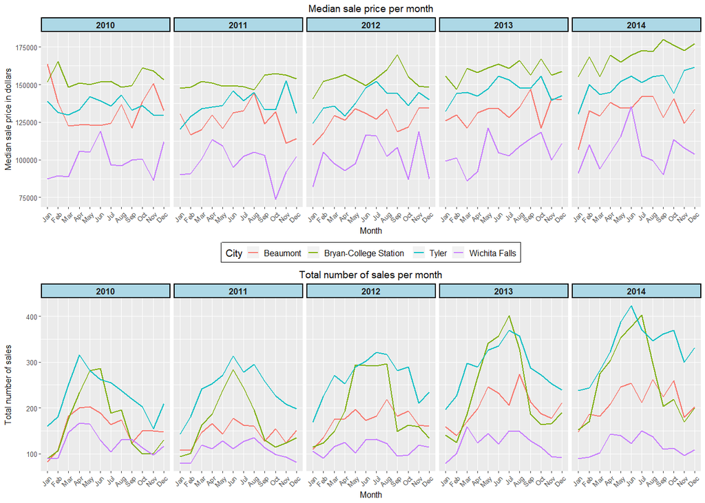

```r
p1 <- ggplot(data = my_data)+
  geom_line(aes(x = factor(month.abb[month], levels = month.abb),
                y=median_price,
                group=city,
                col=city),
            lwd=1
            )+
  facet_wrap(~year, nrow = 1)+
  scale_x_discrete(guide = guide_axis(angle = 45))+
  scale_color_discrete(name = "City")+
  labs(x="Month",
       y="Median sale price in dollars",
       title = "Median sale price per month")+
  theme(plot.title = element_text(hjust = 0.5,
                                  size = 14),
        legend.position = "bottom",
        strip.text = element_text(size = 12,
                                  face = "bold"),
        strip.background = element_rect(color = "black",
                                        fill = "lightblue",
                                        linewidth = 1.2),
        legend.box.background = element_rect(color = "black", linewidth = 1),
        axis.text.x = element_text(size = 10),
        axis.text.y = element_text(size = 10),
        axis.title = element_text(size = 12),
        legend.text = element_text(size = 12),
        legend.title = element_text(size = 14),
        legend.title.align = 0.5)

p2 <- ggplot(data = my_data)+
  geom_line(aes(x = factor(month.abb[month], levels = month.abb),
                y=sales,
                group=city,
                col=city),
            lwd=1
            )+
  facet_wrap(~year, nrow = 1)+
  scale_x_discrete(guide = guide_axis(angle = 45))+
  labs(x="Month",
       y="Total number of sales",
       title = "Total number of sales per month")+
  theme(plot.title = element_text(hjust = 0.5,
                                  size = 14),
        legend.position = "none",
        strip.text = element_text(size = 12,
                                  face = "bold"),
        strip.background = element_rect(color = "black",
                                        fill = "lightblue",
                                        linewidth = 1.2),
        legend.box.background = element_rect(color = "black",
                                             linewidth = 1),
        axis.text.x = element_text(size = 10),
        axis.text.y = element_text(size = 10),
        axis.title = element_text(size = 12),
        legend.text = element_text(size = 12),
        legend.title = element_text(size = 14),
        legend.title.align = 0.5)

plot_grid(p1, p2, ncol = 1, align = "v", rel_heights = c(1.125,1))
```

From the two charts, we see that there was a significative increase in the number of sales in Bryan-College Station and Tyler in 2013 and 2014, and a slight increase in Beaumont from 2011 onwards. The same is not true for the median price. Indeed, it stayed almost constant in Beaumont and Wichita Falls, while there was only a slight increase in the cities of Bryan-College Station and Tyler.